# Exploratory Analysis of Seattle Collisions

Leah Erb

This report explores **collision** report data from **Seattle, Washington, USA**.

# The Dataset

The [Seattle Collisions](https://data-seattlecitygis.opendata.arcgis.com/datasets/collisions) dataset is a compilation of over 200,000 collision reports created by Seattle Police Department (SPD) that were then recorded by Seattle Department of Transportation (SDOT), between the years 2004 and 2018.

# Load data

```r
datafile = '../data/collisions_clean.rda'
load(file = datafile)

# Create df_trim_yrs to contain only complete year's worth of data
# TODO: use logic to trim partial year, remove hardcode
df_full_yrs <- subset(df, year != '2019')
df$hour <- as.integer(df$hour)
```

# Explore

## When

### 1. Collision count by year

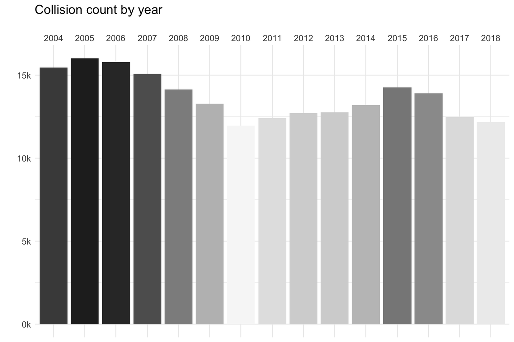

```r
ggplot(data = df_full_yrs %>% count(year), aes(x = year, y = n)) +
    geom_bar(stat = 'identity', aes(fill = n)) +
    mytheme_minimal +
    scale_fill_distiller(palette = 'Greys', direction = 1) +
    labs(title = 'Collision count by year', x = '', y = '') +
    scale_x_discrete(position = 'top') +
    scale_y_continuous(label = unit_format(unit = 'k', scale = 1e-3, sep = ''))
```

**Observations:** There appears to be a 10-is year trend: 5 years down, 5 years up, then going back down.

The first peak, year 2005, was higher than the second peak 10 years later.

I had expected to see a steady increase in Seattle collisions, mirroring population growth. Perhaps I’m wrong about the steady increase in population, or wrong that the number of **reported** collisions have a strong correlation with population. #TODO: import population data and compare rate changes with collision rates by year.

### 2. Collision count by hour

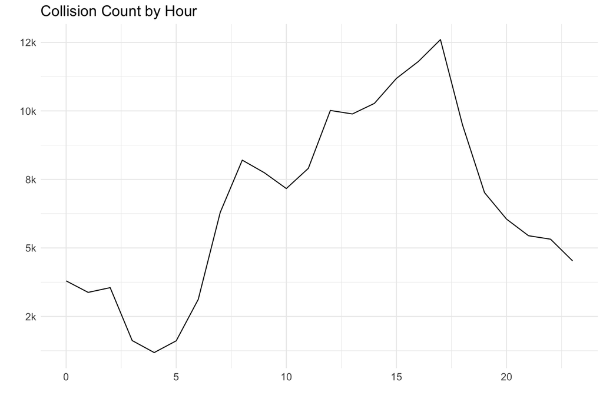

```r
# Plot only records with the hour recorded
df_clean_hr <- subset(df, !(is.na(df$hour)))

ggplot(data = df_clean_hr %>% count(hour),
       aes(x = hour, y = n, group = 1 )) +
    geom_line() +
    labs(title = 'Collision Count by Hour', x = '', y = '') +
    mytheme_minimal  +
    scale_y_continuous(label = unit_format(unit = 'k', scale = 1e-3, sep = ''))
```

### 2b. Collision count by hour, Radial version

TODO: consider different y breaks TODO: consider adding color to parts-of-day

```r
create_radial_plot <- function(data, col_name, title, subtitle) {

    col_name <- enquo(col_name)

    # define inner and outer circle sizes (y)
    max_col <- as.integer(
        data %>%
            group_by(!!col_name) %>%
            summarise(n = n()) %>%
            top_n(1) %>%
            .$n)
    # size the hole for the middle of radial at 5% of the radius
    donut_hole <- max_col * .05
    # define y values for reference circles at 1/3 intervals
    q1 <- max_col * .33
    q2 <- max_col * .66
    q3 <- max_col * .99

    # set circles at quartiles
    v <- data %>% group_by(hour) %>% summarize(n = n())
    q1 <- quantile(v$n)[2]
    q2 <- quantile(v$n)[3]
    q3 <- quantile(v$n)[4]

    # helper function: annotate for each quartile circle
    add_x_annotations <- function(q, qlabel) {
        #x = 4 -> 4am
        annotate('text', x = 4, y = q, label = paste0('Q',qlabel), color = my_ylabel_color, size = 3)
    }

    p <- ggplot() +
        # make radial
        coord_polar(start=-48/360) +
        # draw radius grid manually to avoid extending beyond outer circle
        geom_vline(xintercept = seq(0, 23), colour = my_vline_color, size = 0.2) +
        # draw data 'slices'
        geom_bar(data = data, aes(x = hour), width=1, fill=my_fill_color, color='white', size=0.1)  +
        # add circle grid lines at defined breaks
        geom_hline(yintercept = c(0, q1, q2, q3), colour = my_hline_color, size = 0.2) +
        # mark hours on the 24-hour clock
        scale_x_continuous(breaks = seq(0,23),
                           labels = c('12 am', paste(1:11,'am'), '12 pm', paste(13:23-12, 'pm'))) +
        # make donut hole
        #scale_y_continuous(limits = c(-donut_hole, max_col + donut_hole),
        scale_y_discrete(breaks = c(q1, q2, q3)) +
        # add plot titles
        labs(title = title,
             subtitle = subtitle,
             caption = 'Data source: https://data.seattle.gov  (2004 - 2018)') +
        # define theme options
        theme_minimal() +
        theme(
            plot.margin = unit(c(11, 11, 11, 11), 'points'),
            plot.title = element_text(size = 24, face = 'bold', color = '#333333'),
            plot.subtitle = element_text(size = 12, color = '#333333'),
            plot.caption = element_text(size = 7), #, hjust = 1.8),
            axis.text.x = element_text(size = 12,
                                       # bold font at: 12am, 6am, 12p, 6pm
                                       face = rep(c('bold',rep('plain', 5)), 4)
                                       ),
            # remove axis labels
            axis.title = element_blank(),
            # remove y axis ticks and text
            axis.text.y = element_blank(),
            axis.ticks = element_blank(),
            # remove outermost circle
            panel.grid.major.y = element_blank(),
            # remove 1/2 hour grid lines
            panel.grid.minor = element_blank(),
            # remove hour grid lines, too
            panel.grid.major.x = element_blank()
        )  +
        # annotate x axis lines (circles) with Q1 - Q3
        add_x_annotations(c(q1, q2, q3), c(1,2,3))

    return (p)
}
```

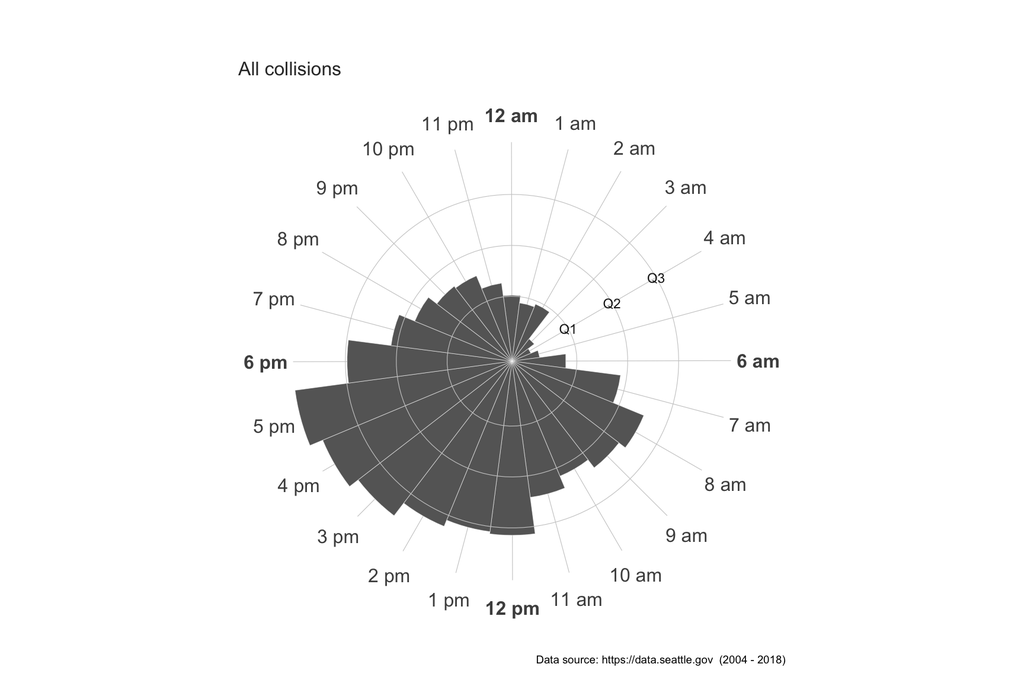

```r
# grideline grey setting
my_vline_color <- 'grey80'
my_fill_color <- 'grey40'
my_hline_color <- 'grey80'
my_ylabel_color <- 'grey10'

# All collisions
create_radial_plot(data = df_clean_hr,
            col_name = hour,
            title = '',
            subtitle = 'All collisions')
```

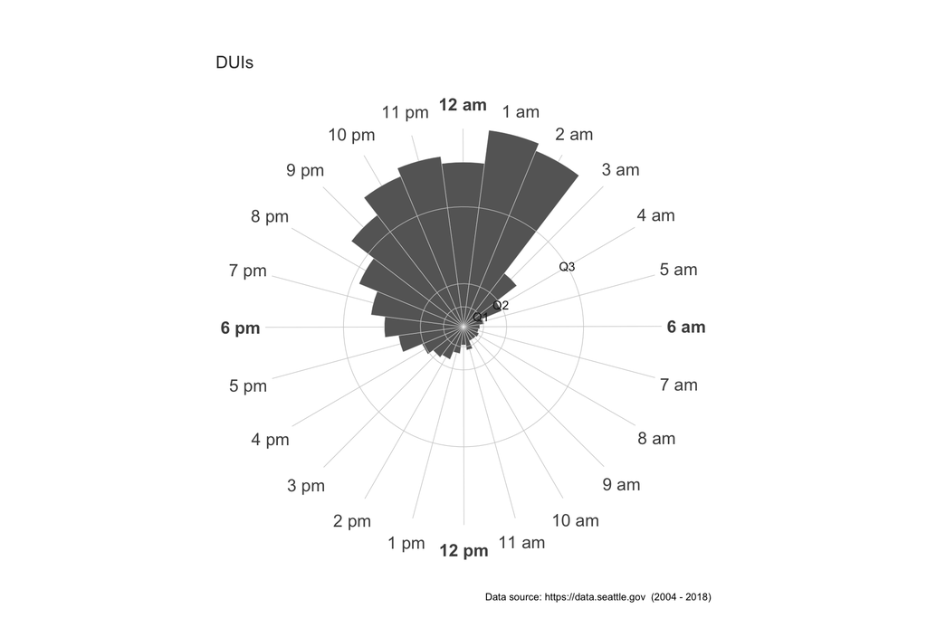

```r
# DUI
create_radial_plot(data = df_clean_hr[which(df_clean_hr$DUI == 'Y'),],
            col_name = hour,
            title = '',
            subtitle = 'DUIs')
```

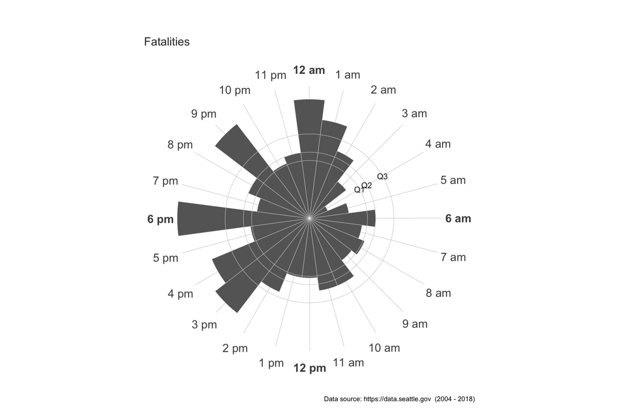

```r
# Fatalities
create_radial_plot(data = df_clean_hr[which(df_clean_hr$FATALITIES > 0),],
            col_name = hour,
            title = '',
            subtitle = 'Fatalities')
```

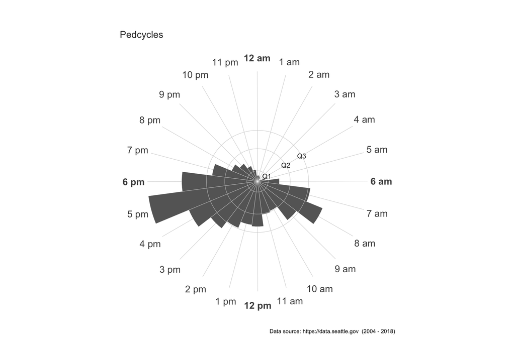

```r
# Pedcycles
create_radial_plot(data = df_clean_hr[which(df_clean_hr$PEDCYLCOUNT > 0),],
            col_name = hour,
            title = '',
            subtitle = 'Pedcycles')
```

**Observations:** All: Collisions tend to rise during commute hours, starting at the lowest point around 4am, reaching a peak at 5pm. DUIs: Most DUI collisions occur in the night hours. Fatalities: A higher number of fatalties happened at 3pm, 4pm, 6pm, 9pm, 12am and 1am. Pedycles: Collisions involving pedcycles (bicycles) occur during morning and evening commutes.

#### 2a. Hourly collisions by day of week

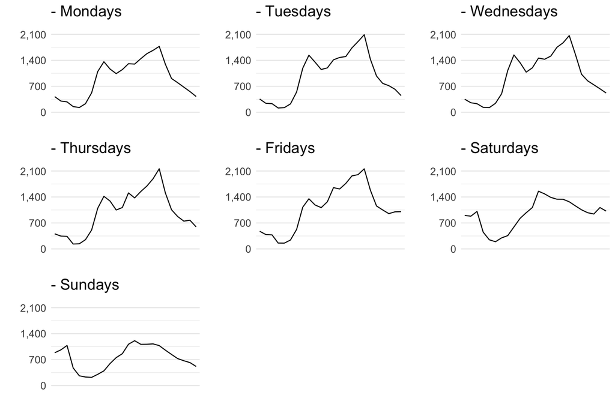

```r
weekend <- c('Saturday', 'Sunday')
weekday <- c('Monday', 'Tuesday', 'Wednesday', 'Thursday', 'Friday')
alldays <- c(weekday, weekend)

# TODO fix y max limit programmatically
plot_hours <- function(day, title) {
    gg <- ggplot(data = df %>%
               filter(!is.na(hour) & weekdays(INCDATE) %in% day) %>%
               count(hour),
           aes(x = hour, y = n, group = 1 )) +
        geom_line() +
        labs(title = paste(title), x = '', y = '') +
        mytheme_minimal  +
        scale_x_discrete(breaks = c(0,4,8,12,16,20,24)) +
        scale_y_continuous(limits = c(0, 2250),
                           breaks = seq(0, 2100, 700),
                           labels = scales::comma)
    return (gg)
}

# create list of plots, one for each day of the week
plot_list <- lapply(
    as.list(alldays), function(x){
    plot_hours(x, paste0('- ', x, 's'))
})

#cowplot::plot_grid(plotlist = plot_list, ncol = 3)

ggarrange(plotlist = plot_list, ncol=3, nrow=3) +
    annotate(geom = 'text', label = 'title', hjust = 0)
```

### By month

### By part of day

### By season

## Who

### Striker, strikee

### Pedestrians, Cyclists

### Parked cars, trains, other

## What

### Collision type

### Property damage, Injuries, Fatalities

## Where

### Address type, Junction type

## Why

### Weather, Road Condition, Lighting

### DUI, Distracted, Speeding

### Traffic volume(?)

## Multivariate

### When and Why

### Who and What

# Summary